# Feature Engineering-03.25.2025

Author

Mohammad Mehralian

# 1 Introduction

The practice of finding better representations of predictors (i.e., features) to improve predictive performance is referred to as “feature engineering.”

In other words, sometimes the predictor variables at hand are not in themselves the best representation to explain a predicted variable.

In these cases, we can use these original predictor variables to derive new, more informative secondary variables.

# 2 Learning objectives

Our learning objectives are to:

- Apply feature engineering concepts to Daymet daily weather data
- Export the feature-engineered data set for further use

# 3 Setup

```r
#install.packages("ggridges")

library(tidyverse)
library(janitor)
```

```r
v_fieldweather <- read_csv("../data/fieldweatherdata.csv")
v_fieldweather
```

```
# A tibble: 254,770 × 19
    year site        lat   lon strength_gtex site_2     tile latitude longitude
   <dbl> <chr>     <dbl> <dbl>         <dbl> <chr>     <dbl>    <dbl>     <dbl>
 1  1980 Altus, OK  34.6 -99.3          25.3 Altus, OK 11201     34.6     -99.3
 2  1980 Altus, OK  34.6 -99.3          25.3 Altus, OK 11201     34.6     -99.3
 3  1980 Altus, OK  34.6 -99.3          25.3 Altus, OK 11201     34.6     -99.3
 4  1980 Altus, OK  34.6 -99.3          25.3 Altus, OK 11201     34.6     -99.3
 5  1980 Altus, OK  34.6 -99.3          25.3 Altus, OK 11201     34.6     -99.3
 6  1980 Altus, OK  34.6 -99.3          25.3 Altus, OK 11201     34.6     -99.3
 7  1980 Altus, OK  34.6 -99.3          25.3 Altus, OK 11201     34.6     -99.3
 8  1980 Altus, OK  34.6 -99.3          25.3 Altus, OK 11201     34.6     -99.3
 9  1980 Altus, OK  34.6 -99.3          25.3 Altus, OK 11201     34.6     -99.3
10  1980 Altus, OK  34.6 -99.3          25.3 Altus, OK 11201     34.6     -99.3
# ℹ 254,760 more rows
# ℹ 10 more variables: altitude <dbl>, year_2 <dbl>, yday <dbl>, dayl_s <dbl>,
#   prcp_mm_day <dbl>, srad_w_m_2 <dbl>, swe_kg_m_2 <dbl>, tmax_deg_c <dbl>,
#   tmin_deg_c <dbl>, vp_pa <dbl>
```

Our data set contains **254,770** rows comprised by **698** site-years and **365** days/site-year worth of weather data.

```r
fieldweather <- clean_names(v_fieldweather)
fieldweather
```

```
# A tibble: 254,770 × 19
    year site        lat   lon strength_gtex site_2     tile latitude longitude
   <dbl> <chr>     <dbl> <dbl>         <dbl> <chr>     <dbl>    <dbl>     <dbl>
 1  1980 Altus, OK  34.6 -99.3          25.3 Altus, OK 11201     34.6     -99.3
 2  1980 Altus, OK  34.6 -99.3          25.3 Altus, OK 11201     34.6     -99.3
 3  1980 Altus, OK  34.6 -99.3          25.3 Altus, OK 11201     34.6     -99.3
 4  1980 Altus, OK  34.6 -99.3          25.3 Altus, OK 11201     34.6     -99.3
 5  1980 Altus, OK  34.6 -99.3          25.3 Altus, OK 11201     34.6     -99.3
 6  1980 Altus, OK  34.6 -99.3          25.3 Altus, OK 11201     34.6     -99.3
 7  1980 Altus, OK  34.6 -99.3          25.3 Altus, OK 11201     34.6     -99.3
 8  1980 Altus, OK  34.6 -99.3          25.3 Altus, OK 11201     34.6     -99.3
 9  1980 Altus, OK  34.6 -99.3          25.3 Altus, OK 11201     34.6     -99.3
10  1980 Altus, OK  34.6 -99.3          25.3 Altus, OK 11201     34.6     -99.3
# ℹ 254,760 more rows
# ℹ 10 more variables: altitude <dbl>, year_2 <dbl>, yday <dbl>, dayl_s <dbl>,
#   prcp_mm_day <dbl>, srad_w_m_2 <dbl>, swe_kg_m_2 <dbl>, tmax_deg_c <dbl>,
#   tmin_deg_c <dbl>, vp_pa <dbl>
```

# 4 EDA

```r
summary(fieldweather)
```

```
      year          site                lat             lon
 Min.   :1980   Length:254770      Min.   :26.16   Min.   :-120.25
 1st Qu.:1987   Class :character   1st Qu.:31.92   1st Qu.:-104.40
 Median :1996   Mode  :character   Median :32.84   Median : -97.75
 Mean   :1997                      Mean   :32.97   Mean   : -97.97
 3rd Qu.:2007                      3rd Qu.:34.66   3rd Qu.: -90.10
 Max.   :2020                      Max.   :36.99   Max.   : -76.58
 strength_gtex      site_2               tile          latitude
 Min.   :19.67   Length:254770      Min.   :10482   Min.   :26.16
 1st Qu.:28.35   Class :character   1st Qu.:10849   1st Qu.:31.92
 Median :30.45   Mode  :character   Median :11022   Median :32.84
 Mean   :30.37                      Mean   :11025   Mean   :32.97
 3rd Qu.:32.58                      3rd Qu.:11201   3rd Qu.:34.66
 Max.   :37.94                      Max.   :11392   Max.   :36.99
   longitude          altitude          year_2          yday
 Min.   :-120.25   Min.   :   7.0   Min.   :1980   Min.   :  1
 1st Qu.:-104.40   1st Qu.:  67.0   1st Qu.:1987   1st Qu.: 92
 Median : -97.75   Median : 132.0   Median :1996   Median :183
 Mean   : -97.97   Mean   : 374.1   Mean   :1997   Mean   :183
 3rd Qu.: -90.10   3rd Qu.: 571.0   3rd Qu.:2007   3rd Qu.:274
 Max.   : -76.58   Max.   :2132.0   Max.   :2020   Max.   :365
     dayl_s       prcp_mm_day        srad_w_m_2      swe_kg_m_2
 Min.   :34049   Min.   :  0.000   Min.   : 36.1   Min.   :  0.0000
 1st Qu.:37915   1st Qu.:  0.000   1st Qu.:286.8   1st Qu.:  0.0000
 Median :43200   Median :  0.000   Median :374.7   Median :  0.0000
 Mean   :43200   Mean   :  2.308   Mean   :363.6   Mean   :  0.2957
 3rd Qu.:48485   3rd Qu.:  0.000   3rd Qu.:449.4   3rd Qu.:  0.0000
 Max.   :52351   Max.   :230.160   Max.   :708.6   Max.   :151.2000
   tmax_deg_c       tmin_deg_c         vp_pa
 Min.   :-14.79   Min.   :-28.59   Min.   :  51.57
 1st Qu.: 18.48   1st Qu.:  3.88   1st Qu.: 631.70
 Median : 26.25   Median : 11.50   Median :1024.27
 Mean   : 24.94   Mean   : 10.99   Mean   :1262.81
 3rd Qu.: 32.29   3rd Qu.: 18.97   3rd Qu.:1844.35
 Max.   : 49.07   Max.   : 31.88   Max.   :4027.17
```

the mean is sensitive to outliers while the median is not. Normaly distributed: mean and media are pretty close.

Let’s create some density plots to explore the weather data distributions.

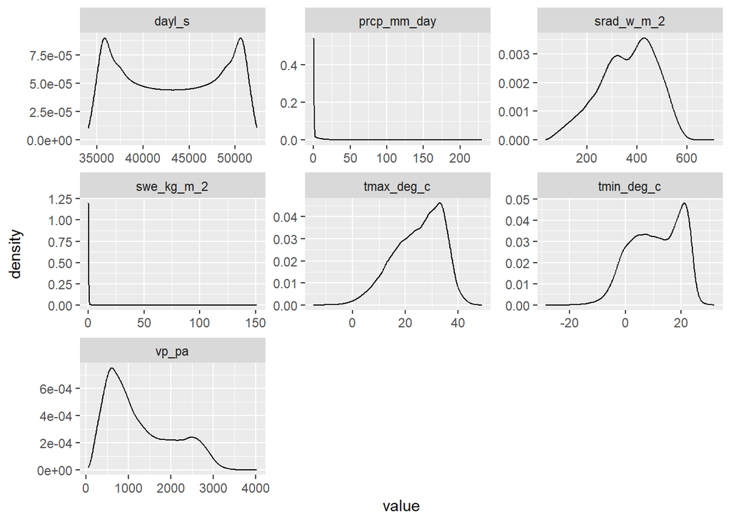

```r
fieldweather %>%
  pivot_longer(cols = dayl_s : vp_pa) %>%
  ggplot(aes(x= value)) +
  geom_density()+
  facet_wrap(.~name, scales = "free")
```

# 5 Feature engineering

Let’s take another look at the data at hand:

```r
fieldweather
```

```
# A tibble: 254,770 × 19
    year site        lat   lon strength_gtex site_2     tile latitude longitude
   <dbl> <chr>     <dbl> <dbl>         <dbl> <chr>     <dbl>    <dbl>     <dbl>
 1  1980 Altus, OK  34.6 -99.3          25.3 Altus, OK 11201     34.6     -99.3
 2  1980 Altus, OK  34.6 -99.3          25.3 Altus, OK 11201     34.6     -99.3
 3  1980 Altus, OK  34.6 -99.3          25.3 Altus, OK 11201     34.6     -99.3
 4  1980 Altus, OK  34.6 -99.3          25.3 Altus, OK 11201     34.6     -99.3
 5  1980 Altus, OK  34.6 -99.3          25.3 Altus, OK 11201     34.6     -99.3
 6  1980 Altus, OK  34.6 -99.3          25.3 Altus, OK 11201     34.6     -99.3
 7  1980 Altus, OK  34.6 -99.3          25.3 Altus, OK 11201     34.6     -99.3
 8  1980 Altus, OK  34.6 -99.3          25.3 Altus, OK 11201     34.6     -99.3
 9  1980 Altus, OK  34.6 -99.3          25.3 Altus, OK 11201     34.6     -99.3
10  1980 Altus, OK  34.6 -99.3          25.3 Altus, OK 11201     34.6     -99.3
# ℹ 254,760 more rows
# ℹ 10 more variables: altitude <dbl>, year_2 <dbl>, yday <dbl>, dayl_s <dbl>,
#   prcp_mm_day <dbl>, srad_w_m_2 <dbl>, swe_kg_m_2 <dbl>, tmax_deg_c <dbl>,
#   tmin_deg_c <dbl>, vp_pa <dbl>
```

Currently, we have weather data for each site-year at a **daily** time interval.

Although this level of temporal resolution is great, plant outputs like yield or quality rarely respond to weather events that occur in one given day (unless it is a severe event like flooding or tornado).

Rather, plants respond to the cumulative effects of weather across many days.

How could we use this understanding to create new features from the current ones?

## 5.1 Quiz - go to eLC

There are **two components** that we can consider when feature engineering weather data:

1. Summarizing time **window size**
- Weekly
- Monthly
- Every 2 months
- Growing season
- Based on crop growth stages
- Other?
2. Summarizing **function**
- Mean
- Median
- Minimum
- Maximum
- Standard deviation

In the next section, let’s use the following:  
- Summarizing time window size: **monthly**  
- Summarizing function: **mean** or **sum**

## 5.2 Quiz - go to eLC

Let’s take a look into date formats in R:  
https://www.r-bloggers.com/2013/08/date-formats-in-r/

A great package to work with dates and times in R is called **lubridate**, see vignette here: https://lubridate.tidyverse.org/index.html

Next, let’s create a column containing the month information.

```r
fe_month <- fieldweather %>%
  # Selecting needed variables
  dplyr::select(year, site, lat, lon,
                strength_gtex,
                yday,
                dayl.s = dayl_s,
                prcp.mm = prcp_mm_day,
                srad.wm2 = srad_w_m_2,
                tmax.c = tmax_deg_c,
                tmin.c = tmin_deg_c,
                vp.pa = vp_pa
                ) %>%
  # Creating a date class variable
mutate(data_chr = paste0(year, "/", yday)) %>%
  mutate(date = as.Date(data_chr, "%Y/%j")) %>%

  # Extracting month from date
mutate(month = month(date)) %>%
  mutate(month_abb = month(date, label = T))

fe_month
```

```
# A tibble: 254,770 × 16
    year site       lat   lon strength_gtex  yday dayl.s prcp.mm srad.wm2 tmax.c
   <dbl> <chr>    <dbl> <dbl>         <dbl> <dbl>  <dbl>   <dbl>    <dbl>  <dbl>
 1  1980 Altus, …  34.6 -99.3          25.3     1 35013.       0     313.  13.4
 2  1980 Altus, …  34.6 -99.3          25.3     2 35046.       0     244.  11.3
 3  1980 Altus, …  34.6 -99.3          25.3     3 35082.       0     188.   5.86
 4  1980 Altus, …  34.6 -99.3          25.3     4 35120.       0     103.   2.13
 5  1980 Altus, …  34.6 -99.3          25.3     5 35162.       0     173.   4.67
 6  1980 Altus, …  34.6 -99.3          25.3     6 35205.       0     322.  17.7
 7  1980 Altus, …  34.6 -99.3          25.3     7 35252.       0     235.   4.07
 8  1980 Altus, …  34.6 -99.3          25.3     8 35301.       0     280.   6.93
 9  1980 Altus, …  34.6 -99.3          25.3     9 35353.       0     293.   9.88
10  1980 Altus, …  34.6 -99.3          25.3    10 35407.       0     329.  20.2
# ℹ 254,760 more rows
# ℹ 6 more variables: tmin.c <dbl>, vp.pa <dbl>, data_chr <chr>, date <date>,
#   month <dbl>, month_abb <ord>
```

Now, let’s summarize daily weather variables based on month.

```r
fe_month_sum <- fe_month %>%
  group_by(year, site, month_abb, strength_gtex) %>%
  summarise(across(.cols = c(dayl.s,
                             srad.wm2,
                             tmax.c,
                             tmin.c,
                             vp.pa),
                   .fns = mean,
                   .names = "mean_{.col}"),
            across(.cols = prcp.mm,
                   .fns = sum,
                   .names = "sum_{.col}")
            ) %>%
  ungroup()
fe_month_sum
```

```
# A tibble: 8,376 × 10
    year site      month_abb strength_gtex mean_dayl.s mean_srad.wm2 mean_tmax.c
   <dbl> <chr>     <ord>             <dbl>       <dbl>         <dbl>       <dbl>
 1  1980 Altus, OK Jan                25.3      35873.          242.        10.2
 2  1980 Altus, OK Feb                25.3      38729.          366.        13.8
 3  1980 Altus, OK Mar                25.3      42536.          391.        18.9
 4  1980 Altus, OK Apr                25.3      46521.          450.        24.6
 5  1980 Altus, OK May                25.3      49829.          403.        27.9
 6  1980 Altus, OK Jun                25.3      51429.          427.        36.6
 7  1980 Altus, OK Jul                25.3      50561.          409.        40.5
 8  1980 Altus, OK Aug                25.3      47608.          396.        38.1
 9  1980 Altus, OK Sep                25.3      43732.          381.        32.1
10  1980 Altus, OK Oct                25.3      39757.          378.        26.2
# ℹ 8,366 more rows
# ℹ 3 more variables: mean_tmin.c <dbl>, mean_vp.pa <dbl>, sum_prcp.mm <dbl>
```

8,376 rows because 698 site-years x 12 months.

Let’s check tmax.c and prcp.mm for the first site-year and month.

```r
fe_month %>%
  filter(year == 1980 &
           site == "Altus, OK" &
           month_abb == "Jan") %>%
  summarise(tmax.c = mean(tmax.c),
            prcp.mm = sum(prcp.mm))
```

```
# A tibble: 1 × 2
  tmax.c prcp.mm
   <dbl>   <dbl>
1   10.2    61.6
```

Now, what if we wanted to have month as part of the column name instead?

```r
fe_month_sum_wide <- fe_month_sum %>%
  pivot_longer(cols = mean_dayl.s:sum_prcp.mm)%>%
  mutate(varname = paste0(name, "_", month_abb)) %>%
  dplyr::select(-name, -month_abb) %>%
  pivot_wider(names_from = varname,
              values_from = value) %>%

  # Rounding to one decimal point
mutate(across(3:75, ~round(., 1)))

fe_month_sum_wide
```

```
# A tibble: 698 × 75
    year site    strength_gtex mean_dayl.s_Jan mean_srad.wm2_Jan mean_tmax.c_Jan
   <dbl> <chr>           <dbl>           <dbl>             <dbl>           <dbl>
 1  1980 Altus,…          25.3          35873.              242.            10.2
 2  1980 Ames P…          27.2          35743.              215.             9.2
 3  1980 Artesi…          26            36359               279.            13.4
 4  1980 Auburn…          24.8          36420.              240.            13.9
 5  1980 Beevil…          24.5          37494.              277             19.9
 6  1980 Belle …          28.1          35873.              224.             9.7
 7  1980 Bossie…          25.9          36451.              221.            13.2
 8  1980 Chicka…          25.9          35760.              244              9.5
 9  1980 Clarkd…          26.1          35678.              265.             5.8
10  1980 Colleg…          27.1          36941.              254             15.8
# ℹ 688 more rows
# ℹ 69 more variables: mean_tmin.c_Jan <dbl>, mean_vp.pa_Jan <dbl>,
#   sum_prcp.mm_Jan <dbl>, mean_dayl.s_Feb <dbl>, mean_srad.wm2_Feb <dbl>,
#   mean_tmax.c_Feb <dbl>, mean_tmin.c_Feb <dbl>, mean_vp.pa_Feb <dbl>,
#   sum_prcp.mm_Feb <dbl>, mean_dayl.s_Mar <dbl>, mean_srad.wm2_Mar <dbl>,
#   mean_tmax.c_Mar <dbl>, mean_tmin.c_Mar <dbl>, mean_vp.pa_Mar <dbl>,
#   sum_prcp.mm_Mar <dbl>, mean_dayl.s_Apr <dbl>, mean_srad.wm2_Apr <dbl>, …
```

across function is used when applying to many variables

Notice how we are back at **698** rows.

For each site-year, we have one piece of weather information for each of the weather variables (as opposed to the original Daymet data that had 365 rows per site-year).

Let’s explore our newly engineered variables.

# 6 EDA round 2

Let’s make a ridge plot to visualize the distribution of one variable over months.

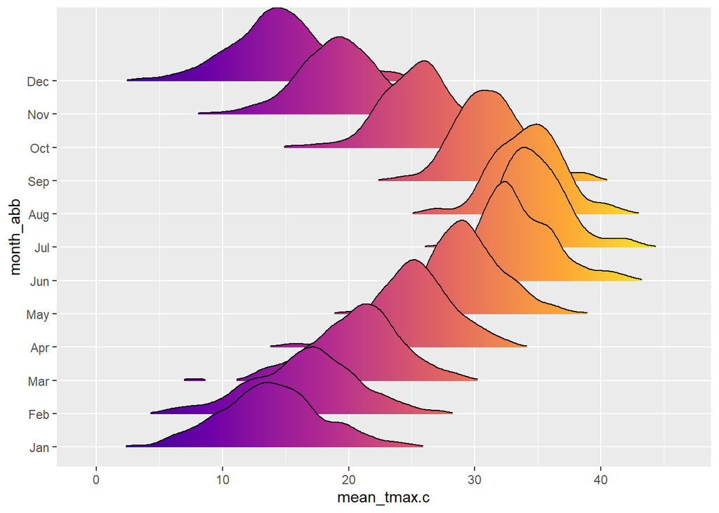

```r
#install.packages("ggridges")
library(ggridges)
ggplot(data = fe_month_sum,
       aes(x = mean_tmax.c,
           y = month_abb,
           fill = stat(x)
           )
       ) +
  geom_density_ridges_gradient(scale = 3,
                               rel_min_height = 0.01) +
  scale_fill_viridis_c(option = "C") +
  theme(legend.position = "none")
```

Now let’s do that for all variables.

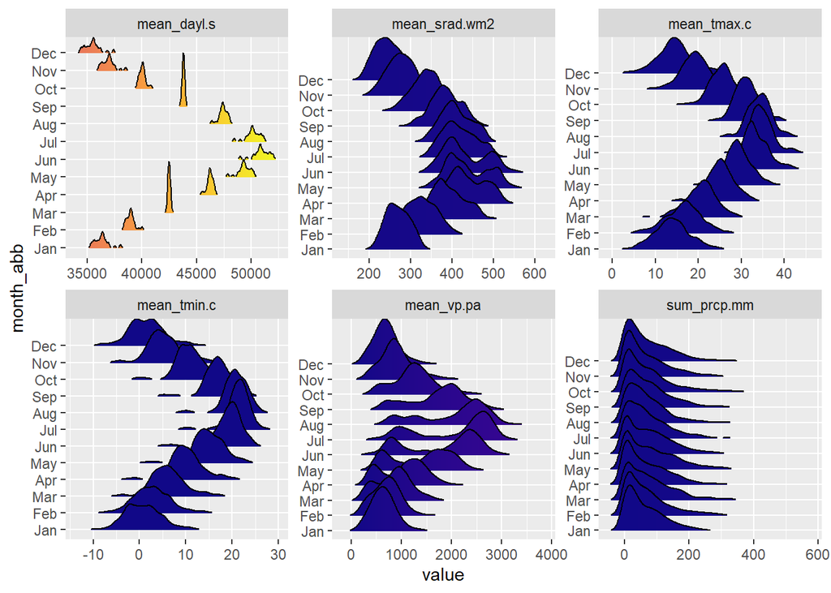

```r
finalplots <- fe_month_sum %>%
  pivot_longer(mean_dayl.s:sum_prcp.mm) %>%
  ggplot(
       aes(x = value,
           y = month_abb,
           fill = stat(x)
           )
       ) +
  geom_density_ridges_gradient(scale = 3,
                               rel_min_height = 0.01) +
  scale_fill_viridis_c(option = "C") +
  theme(legend.position = "none") +
  facet_wrap(~name, scales = "free")

finalplots
```

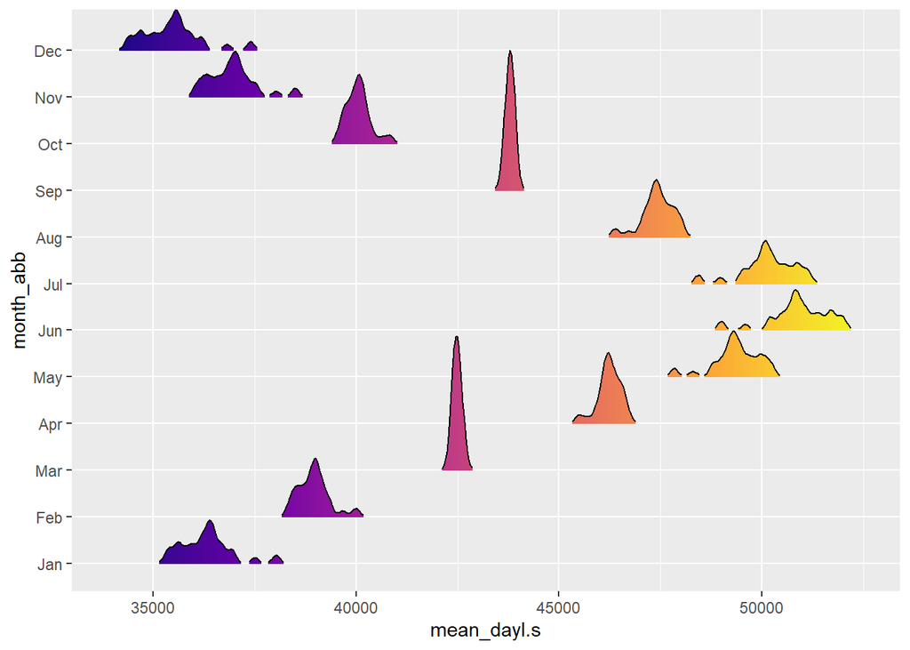

```r
finalplots <- fe_month_sum %>%
  pivot_longer(mean_dayl.s:sum_prcp.mm) %>%
  group_by(name) %>%
  nest()%>%
  mutate(plot = map2(data, name,
                     ~ggplot( data = .x,
       aes(x = value,
           y = month_abb,
           fill = stat(x)
           )
       ) +
  geom_density_ridges_gradient(scale = 3,
                               rel_min_height = 0.01) +
  scale_fill_viridis_c(option = "C") +
  theme(legend.position = "none") +
    labs(x = .y)
                     ))



finalplots$plot[[1]]
```

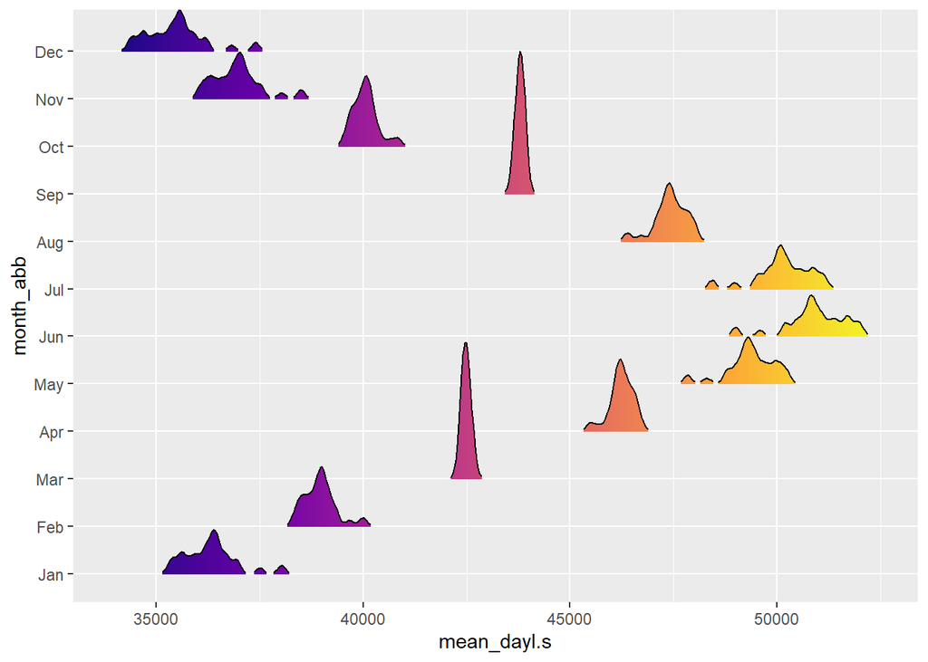

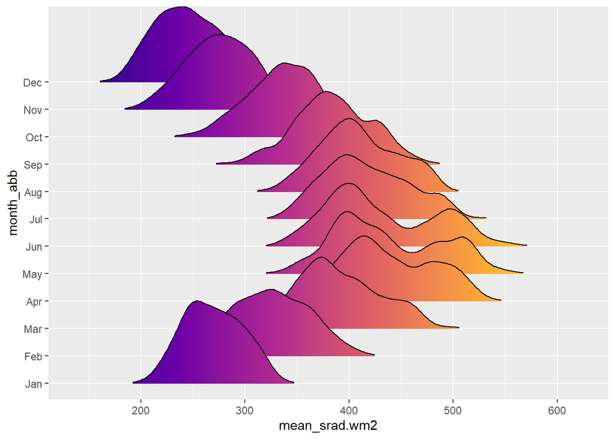

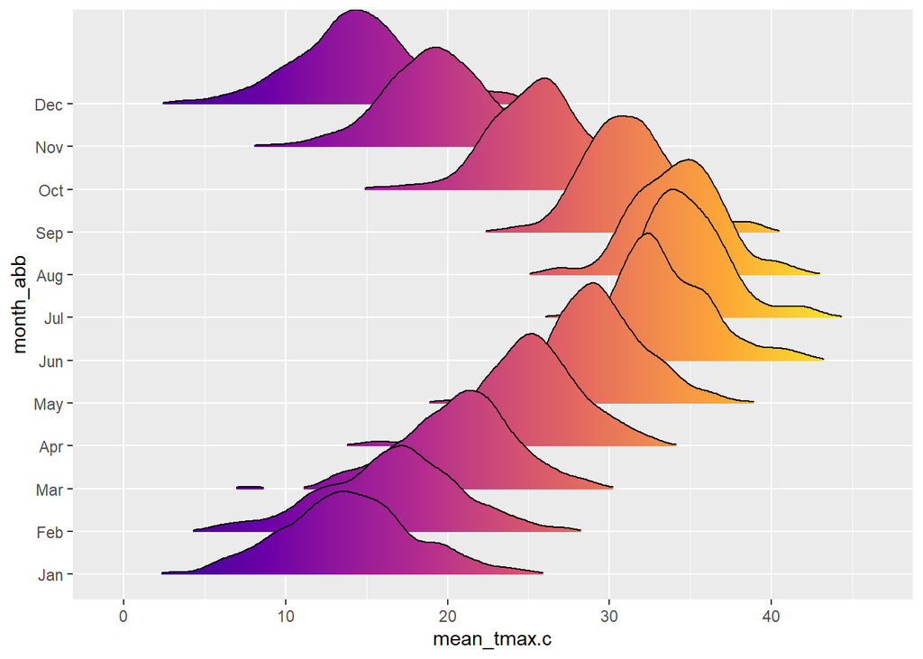

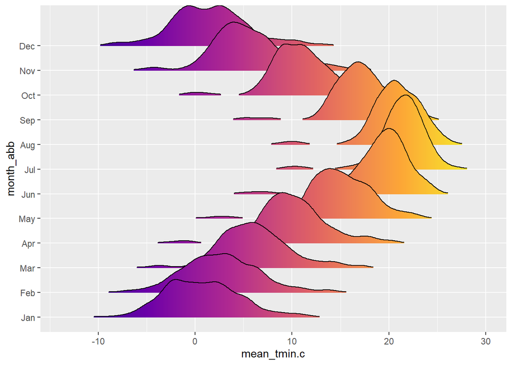

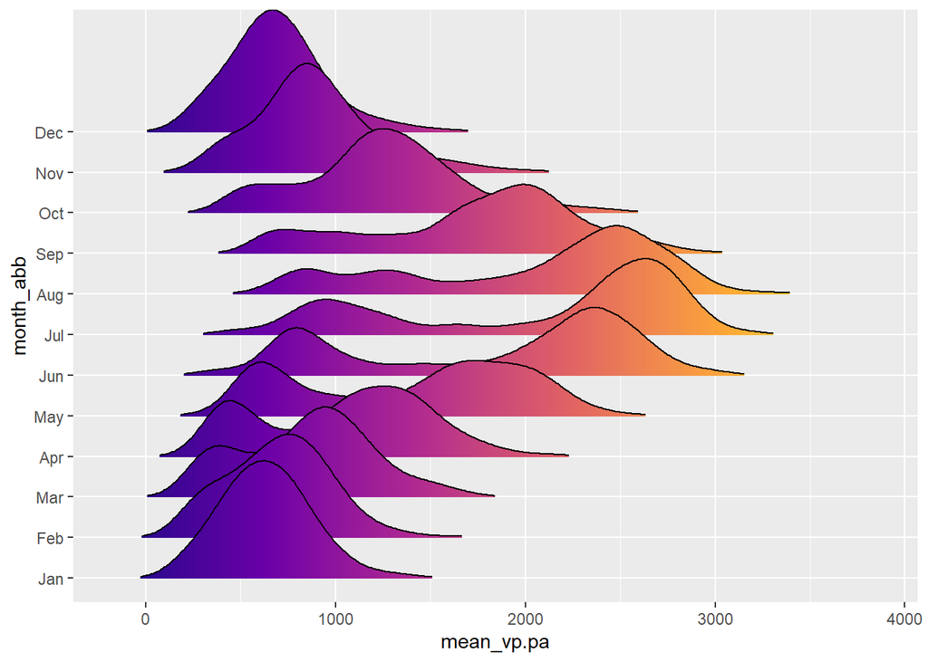

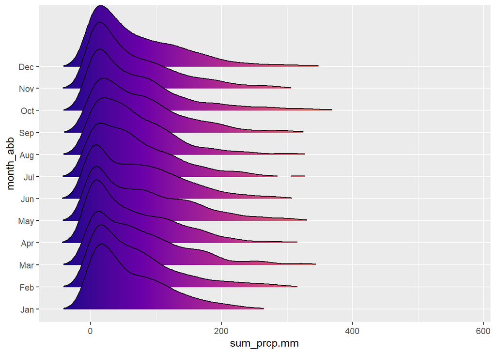

```r
finalplots$plot
```

# 7 Exporting

```r
write_csv(fe_month_sum_wide,
          "../data/weather_monthsum.csv")
```

# 8 Summary

In this exercise, we:  
- Imported the original **7** weather variables from Daymet  
- Feature engineered a total of **72** secondary variables by applying a summarizing window size of **month** and a summarizing function of **mean or sum**.  
- Explored the data distribution of the new variables.  
- Exported to file to be used in subsequent exercises.